# Biostat 203B Homework 2

Due Feb 6 @ 11:59PM

Yuyuan Lin

```r
knitr::opts_chunk$set(echo = TRUE, cache = TRUE, cache.lazy = FALSE,
                      warning = FALSE, message = FALSE)
library(tidyverse)
library(data.table)
library(lubridate)
library(gridExtra)
```

```r
os <- sessionInfo()$running
if (str_detect(os, "Linux")) {
  mimic_path <- "/mnt/mimiciv/1.0"
} else if (str_detect(os, "macOS")) {
  mimic_path <- "/Users/yuyuanlin/Data/mimiciv/1.0"
}
```

In this exercise, we use tidyverse (ggpot2, dplyr, etc) to explore the [MIMIC-IV](https://mimic.mit.edu/docs/iv/) data introduced in [homework 1](https://ucla-biostat-203b.github.io/2022winter/hw/hw1/hw1.html) and to build a cohort of ICU stays.

```r
if (str_detect(os, "Linux")) {
  system(str_c("tree -s -L 2 ", shQuote(mimic_path)), intern = TRUE)
} else if (str_detect(os, "macOS")) {
  system("/opt/homebrew/bin/tree /Users/yuyuanlin/Data/mimiciv/1.0",
         intern = TRUE)
}
```

```
##  [1] "\033[01;34m/Users/yuyuanlin/Data/mimiciv/1.0\033[0m"
##  [2] "├── \033[00mLICENSE.txt\033[0m"
##  [3] "├── \033[00mSHA256SUMS.txt\033[0m"
##  [4] "├── \033[01;34mcore\033[0m"
##  [5] "│   ├── \033[01;31madmissions.csv.gz\033[0m"
##  [6] "│   ├── \033[00mindex.html\033[0m"
##  [7] "│   ├── \033[01;31mpatients.csv.gz\033[0m"
##  [8] "│   └── \033[01;31mtransfers.csv.gz\033[0m"
##  [9] "├── \033[01;34mhosp\033[0m"
## [10] "│   ├── \033[01;31md_hcpcs.csv.gz\033[0m"
## [11] "│   ├── \033[01;31md_icd_diagnoses.csv.gz\033[0m"
## [12] "│   ├── \033[01;31md_icd_procedures.csv.gz\033[0m"
## [13] "│   ├── \033[01;31md_labitems.csv.gz\033[0m"
## [14] "│   ├── \033[01;31mdiagnoses_icd.csv.gz\033[0m"
## [15] "│   ├── \033[01;31mdrgcodes.csv.gz\033[0m"
```

[output cut: 26 more lines]

## Q1. `read.csv` (base R) vs `read_csv` (tidyverse) vs `fread` (data.table)

There are quite a few utilities in R for reading plain text data files. Let us test the speed of reading a moderate sized compressed csv file, `admissions.csv.gz`, by three programs: `read.csv` in base R, `read_csv` in tidyverse, and `fread` in the popular data.table package.

Which function is fastest? Is there difference in the (default) parsed data types? (Hint: R function `system.time` measures run times.)

```r
system.time(read.csv(str_c(mimic_path, "/core/admissions.csv.gz")))
```

```
##    user  system elapsed
##   7.316   0.155   7.498
```

```r
system.time(read_csv(str_c(mimic_path, "/core/admissions.csv.gz"),
                     show_col_types = FALSE))
```

```
##    user  system elapsed
##   2.563   1.214   1.127
```

```r
system.time(fread(str_c(mimic_path, "/core/admissions.csv.gz")))
```

```
##    user  system elapsed
##   0.945   0.164   1.136
```

By default, `read_csv` and `read.csv` read in comma separated values; `fread` can detect the type of file and select field separator character automatically.

For later questions, we stick to the tidyverse.

## Q2. ICU stays

`icustays.csv.gz` (https://mimic.mit.edu/docs/iv/modules/icu/icustays/) contains data about Intensive Care Units (ICU) stays. The first 10 lines are

```r
system(
  str_c(
    "zcat < ",
    shQuote(str_c(mimic_path, "/icu/icustays.csv.gz")),
    " | head"
    ),
  intern = TRUE
)
```

```
##  [1] "subject_id,hadm_id,stay_id,first_careunit,last_careunit,intime,outtime,los"
##  [2] "17867402,24528534,31793211,Trauma SICU (TSICU),Trauma SICU (TSICU),2154-03-03 04:11:00,2154-03-04 18:16:56,1.5874537037037035"
##  [3] "14435996,28960964,31983544,Trauma SICU (TSICU),Trauma SICU (TSICU),2150-06-19 17:57:00,2150-06-22 18:33:54,3.025625"
##  [4] "17609946,27385897,33183475,Trauma SICU (TSICU),Trauma SICU (TSICU),2138-02-05 18:54:00,2138-02-15 12:42:05,9.741724537037038"
##  [5] "18966770,23483021,34131444,Trauma SICU (TSICU),Trauma SICU (TSICU),2123-10-25 10:35:00,2123-10-25 18:59:47,0.35054398148148147"
##  [6] "12776735,20817525,34547665,Neuro Stepdown,Neuro Stepdown,2200-07-12 00:33:00,2200-07-13 16:44:40,1.6747685185185184"
##  [7] "10215159,24283593,34569476,Trauma SICU (TSICU),Trauma SICU (TSICU),2124-09-20 15:05:29,2124-09-21 22:06:58,1.2926967592592593"
##  [8] "14489052,26516390,35056286,Trauma SICU (TSICU),Trauma SICU (TSICU),2118-10-26 10:33:56,2118-10-26 20:28:10,0.4126620370370371"
##  [9] "15914763,28906020,36909804,Trauma SICU (TSICU),Trauma SICU (TSICU),2176-12-14 12:00:00,2176-12-17 11:47:01,2.9909837962962964"
## [10] "16256226,20013290,39289362,Neuro Stepdown,Neuro Stepdown,2150-12-20 16:09:08,2150-12-21 14:58:40,0.9510648148148149"
```

1. Import `icustatys.csv.gz` as a tibble `icustays_tble`.

```r
icustays_tble <- read_csv(str_c(mimic_path, "/icu/icustays.csv.gz"),
                          show_col_types = FALSE)
```

2. How many unique `subject_id`? Can a `subject_id` have multiple ICU stays?

```r
length(unique(icustays_tble$subject_id))
```

```
## [1] 53150
```

```r
nrow(icustays_tble)
```

```
## [1] 76540
```

**Answer:** There were 53150 unique `subject_id`s, one `subject_id` can have more than one ICU stays since the total number of records is 76540 (greater than 53150).

3. For each `subject_id`, let’s only keep the first ICU stay in the tibble `icustays_tble`.

```r
icustays_tble <- icustays_tble %>%
  arrange(subject_id, intime) %>%
  filter(!duplicated(subject_id))

nrow(icustays_tble)
```

```
## [1] 53150
```

## Q3. `admission` data

Information of the patients admitted into hospital is available in `admissions.csv.gz`. See https://mimic.mit.edu/docs/iv/modules/core/admissions/ for details of each field in this file. The first 10 lines are

```r
system(
  str_c(
    "zcat < ",
    shQuote(str_c(mimic_path, "/core/admissions.csv.gz")),
    " | head"
    ),
  intern = TRUE
)
```

```
##  [1] "subject_id,hadm_id,admittime,dischtime,deathtime,admission_type,admission_location,discharge_location,insurance,language,marital_status,ethnicity,edregtime,edouttime,hospital_expire_flag"
##  [2] "14679932,21038362,2139-09-26 14:16:00,2139-09-28 11:30:00,,ELECTIVE,,HOME,Other,ENGLISH,SINGLE,UNKNOWN,,,0"
##  [3] "15585972,24941086,2123-10-07 23:56:00,2123-10-12 11:22:00,,ELECTIVE,,HOME,Other,ENGLISH,,WHITE,,,0"
##  [4] "11989120,21965160,2147-01-14 09:00:00,2147-01-17 14:25:00,,ELECTIVE,,HOME,Other,ENGLISH,,UNKNOWN,,,0"
##  [5] "17817079,24709883,2165-12-27 17:33:00,2165-12-31 21:18:00,,ELECTIVE,,HOME,Other,ENGLISH,,OTHER,,,0"
##  [6] "15078341,23272159,2122-08-28 08:48:00,2122-08-30 12:32:00,,ELECTIVE,,HOME,Other,ENGLISH,,BLACK/AFRICAN AMERICAN,,,0"
##  [7] "19124609,20517215,2169-03-14 12:44:00,2169-03-20 19:15:00,,ELECTIVE,,HOME,Other,ENGLISH,,UNKNOWN,,,0"
##  [8] "17301855,29732723,2140-06-06 14:23:00,2140-06-08 14:25:00,,ELECTIVE,,HOME,Other,ENGLISH,,WHITE,,,0"
##  [9] "17991012,24298836,2181-07-10 20:28:00,2181-07-12 15:49:00,,ELECTIVE,,HOME,Other,ENGLISH,,WHITE,,,0"
## [10] "16865435,23216961,2185-07-19 02:12:00,2185-07-21 11:50:00,,ELECTIVE,,HOME,Other,ENGLISH,,WHITE,,,0"
```

1. Import `admissions.csv.gz` as a tibble `admissions_tble`.

```r
admissions_tble <- read_csv(str_c(mimic_path, "/core/admissions.csv.gz"),
                            show_col_types = FALSE)
```

2. Let’s only keep the admissions that have a match in `icustays_tble` according to `subject_id` and `hadmi_id`.

```r
admissions_tble <- admissions_tble %>%
  filter(subject_id %in% icustays_tble$subject_id) %>%
  filter(hadm_id %in% icustays_tble$hadm_id)
```

3. Summarize the following variables by graphics.
- admission year

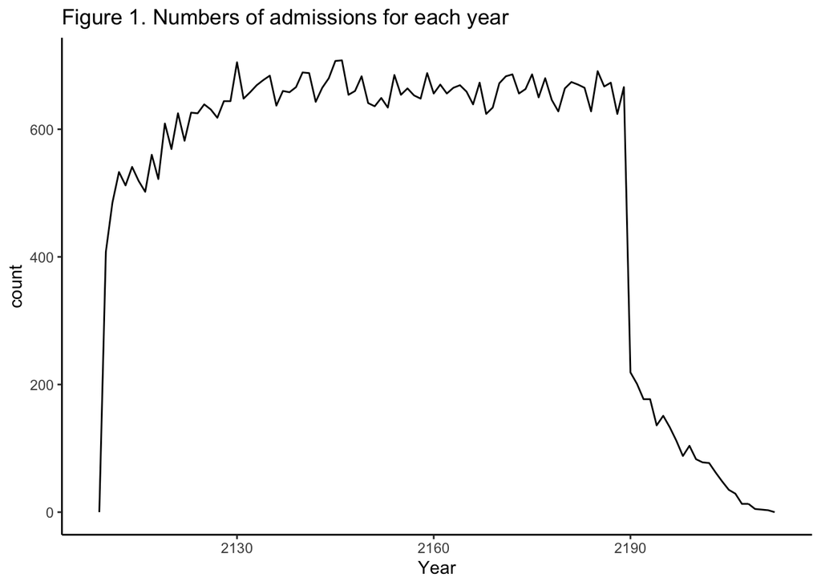

```r
admissions_tble %>%
  mutate(Year = year(admittime)) %>%
  ggplot(mapping = aes(x = Year)) +
  theme_classic() +
  geom_freqpoly(bins = 102) + # there were 102 years in the data set
  labs(title = "Figure 1. Numbers of admissions for each year")
```

- admission month

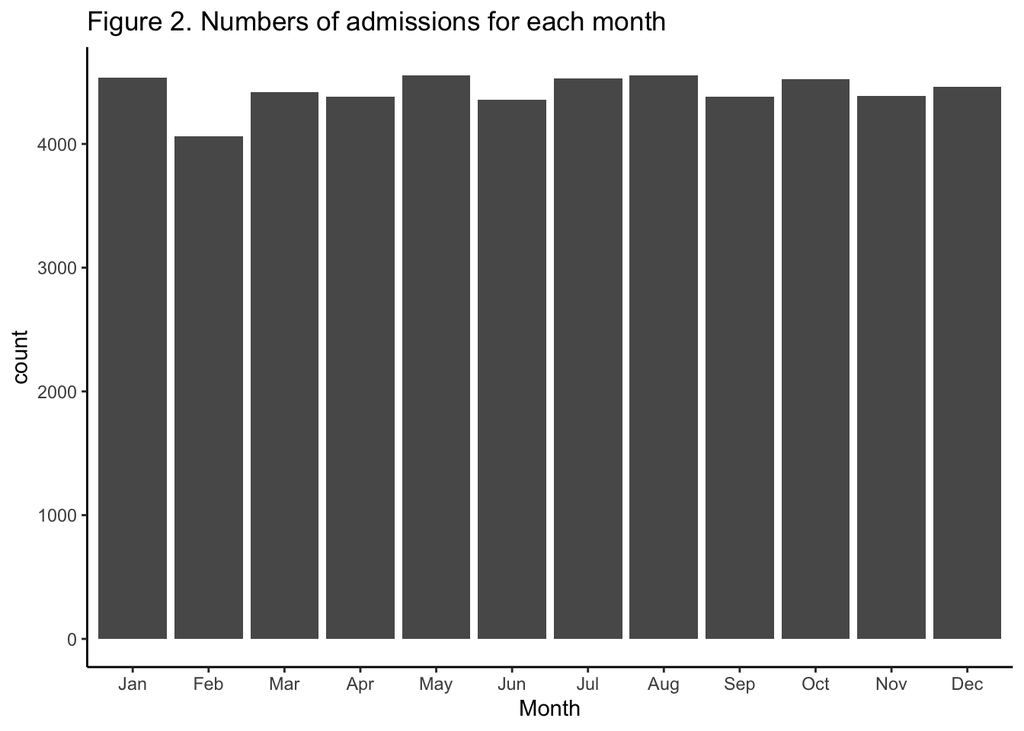

```r
admissions_tble %>%
  mutate(Month = month(admittime, label = TRUE)) %>%
  ggplot(mapping = aes(x = Month)) +
  theme_classic() +
  geom_bar() +
  labs(title = "Figure 2. Numbers of admissions for each month")
```

- admission month day

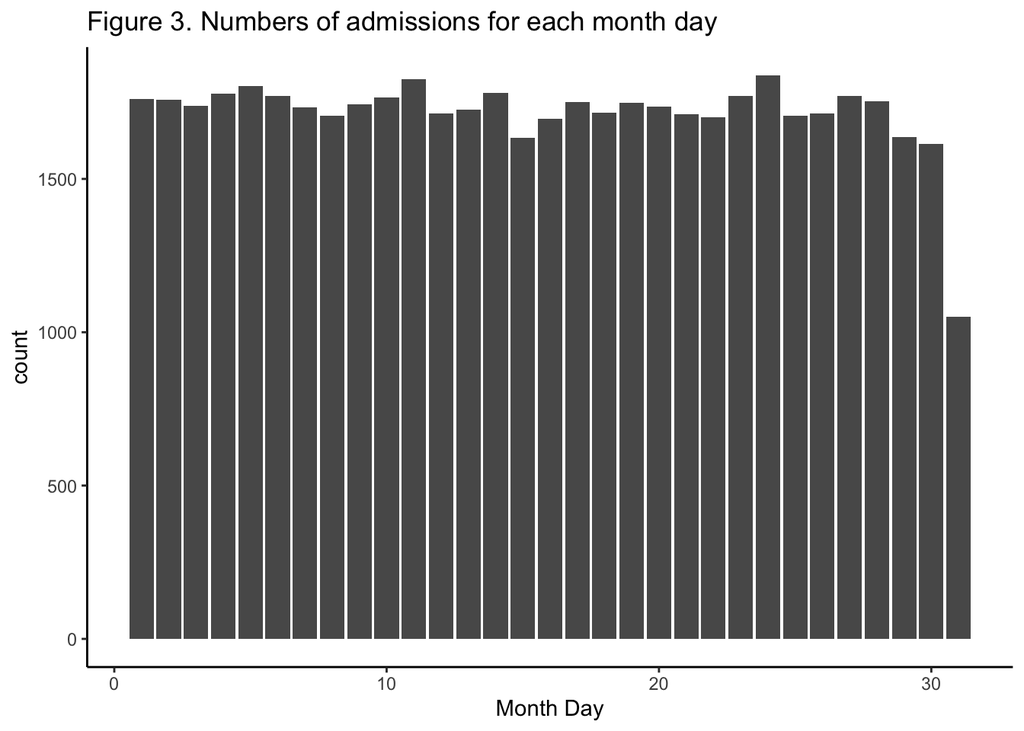

```r
admissions_tble %>%
  mutate(month_day = mday(admittime)) %>%
  ggplot(mapping = aes(x = month_day)) +
  theme_classic() +
  geom_bar() +
  labs(title = "Figure 3. Numbers of admissions for each month day",
       x = "Month Day")
```

- admission week day

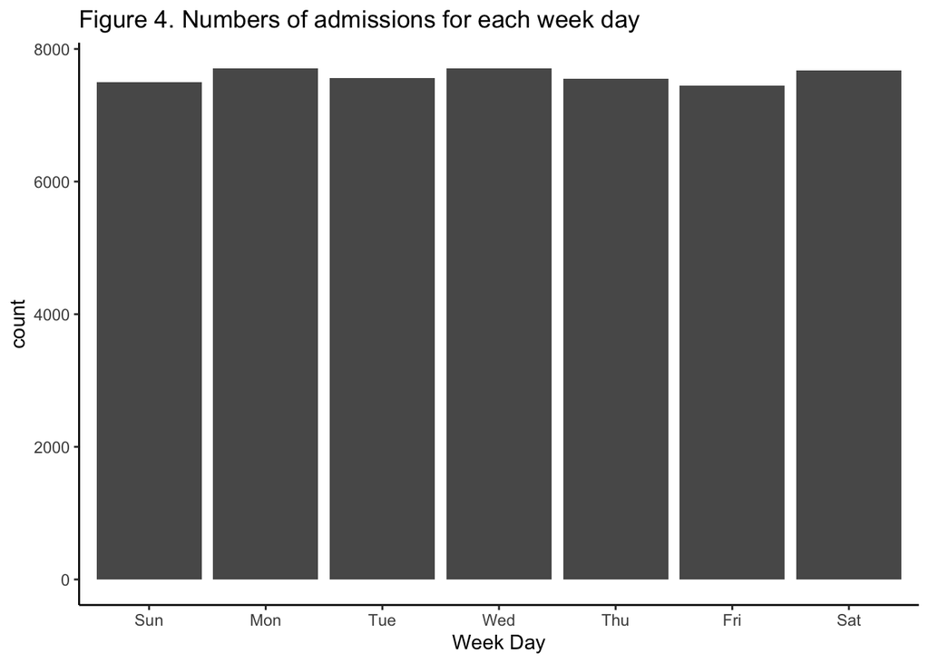

```r
admissions_tble %>%
  mutate(week_day = wday(admittime, label = TRUE)) %>%
  ggplot(mapping = aes(x = week_day)) +
  theme_classic() +
  geom_bar() +
  labs(title = "Figure 4. Numbers of admissions for each week day",
       x = "Week Day")
```

- admission hour (anything unusual?)

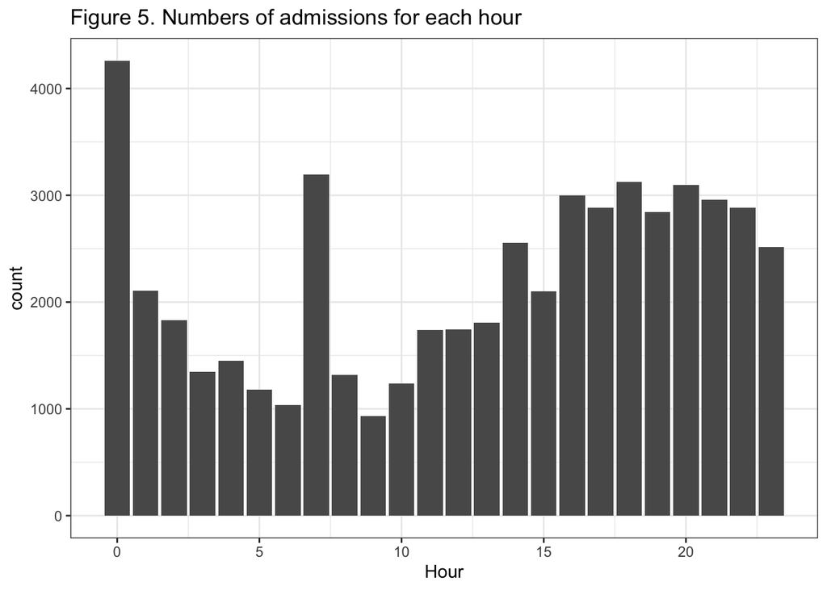

```r
admissions_tble %>%
  mutate(Hour = hour(admittime)) %>%
  ggplot(mapping = aes(x = Hour)) +
  theme_bw() +
  geom_bar() +
  labs(title = "Figure 5. Numbers of admissions for each hour",
       x = "Hour")
```

**Answer:** The admission pattern by hour shows two “unusual” peaks: one at 7 am, another at 12 am. My guess is that 7 am is the opening time for most hospitals. It’s still abnormal that 12 am at midnight has the greatest admission number.

## Q4. `patients` data

Patient information is available in `patients.csv.gz`. See https://mimic.mit.edu/docs/iv/modules/core/patients/ for details of each field in this file. The first 10 lines are

```r
system(
  str_c(
    "zcat < ",
    shQuote(str_c(mimic_path, "/core/patients.csv.gz")),
    " | head"
    ),
  intern = TRUE
)
```

```
##  [1] "subject_id,gender,anchor_age,anchor_year,anchor_year_group,dod"
##  [2] "10000048,F,23,2126,2008 - 2010,"
##  [3] "10002723,F,0,2128,2017 - 2019,"
##  [4] "10003939,M,0,2184,2008 - 2010,"
##  [5] "10004222,M,0,2161,2014 - 2016,"
##  [6] "10005325,F,0,2154,2011 - 2013,"
##  [7] "10007338,F,0,2153,2017 - 2019,"
##  [8] "10008101,M,0,2142,2008 - 2010,"
##  [9] "10009872,F,0,2168,2014 - 2016,"
## [10] "10011333,F,0,2132,2014 - 2016,"
```

1. Import `patients.csv.gz` (https://mimic.mit.edu/docs/iv/modules/core/patients/) as a tibble `patients_tble` and only keep the patients who have a match in `icustays_tble` (according to `subject_id`).

```r
patients_tble <- read_csv(str_c(mimic_path, "/core/patients.csv.gz"),
                          show_col_types = FALSE) %>%
  filter(subject_id %in% icustays_tble$subject_id)
```

2. Summarize variables `gender` and `anchor_age`, and explain any patterns you see.

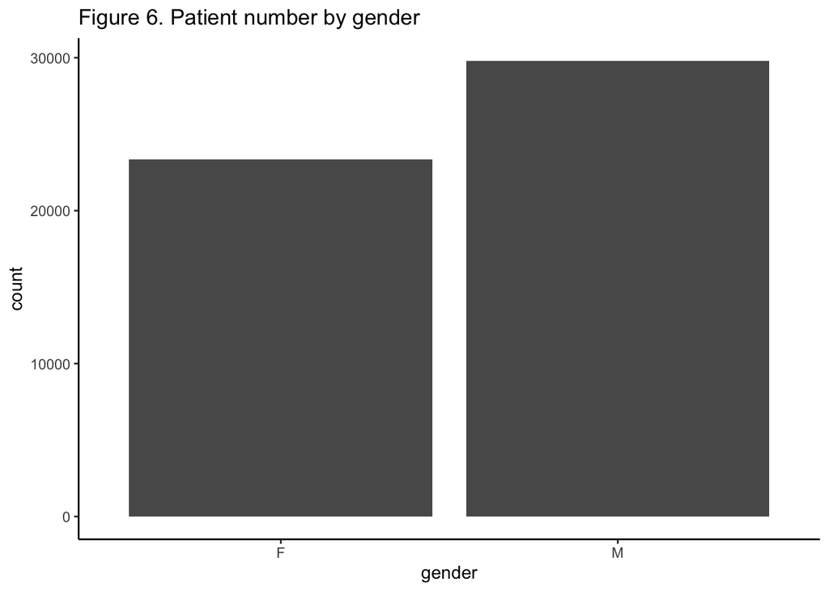

```r
patients_tble %>%
  ggplot(mapping = aes(x = gender)) +
  geom_bar() +
  theme_classic() +
  labs(title = "Figure 6. Patient number by gender")
```

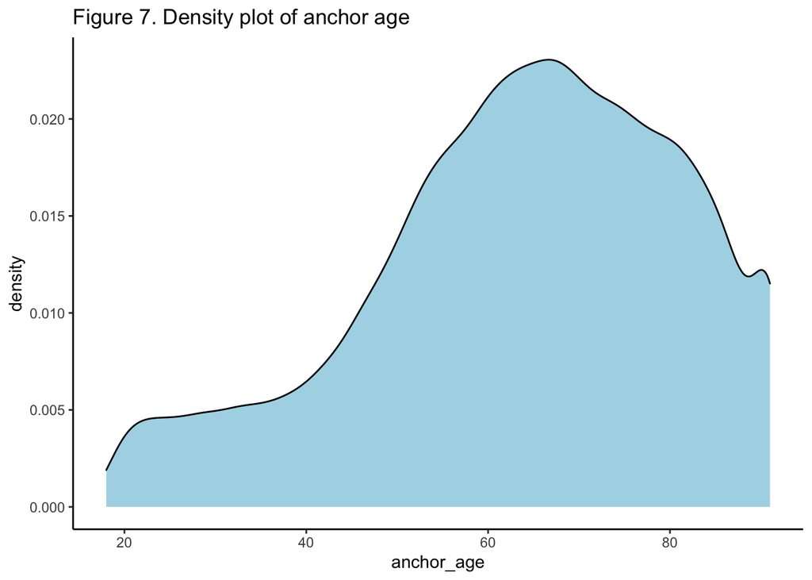

```r
patients_tble %>%
  ggplot(mapping = aes(x = anchor_age)) +
  geom_density(fill = "light blue") +
  theme_classic() +
  labs(title = "Figure 7. Density plot of anchor age")
```

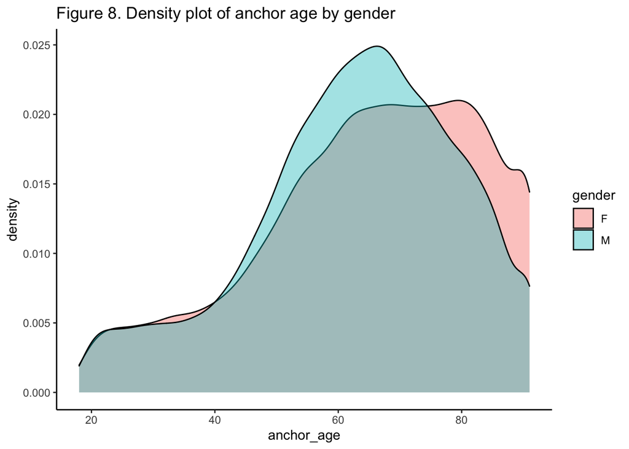

```r
patients_tble %>%
  ggplot(mapping = aes(x = anchor_age, group = gender)) +
  geom_density(aes(fill = gender), alpha = 0.4) +
  theme_classic() +
  labs(title = "Figure 8. Density plot of anchor age by gender")
```

**Answer:** There are more male patients admitted to ICU than female patients. Most patients admitted to ICU aged between 40 to 80-year-old. The peak of age distribution is around 65-70-year-old. Male patients seem to have a slightly younger age distribution compared to females.

## Q5. Lab results

`labevents.csv.gz` (https://mimic.mit.edu/docs/iv/modules/hosp/labevents/) contains all laboratory measurements for patients. The first 10 lines are

```r
system(
  str_c(
    "zcat < ",
    shQuote(str_c(mimic_path, "/hosp/labevents.csv.gz")),
    " | head"
    ),
  intern = TRUE
)
```

```
##  [1] "labevent_id,subject_id,hadm_id,specimen_id,itemid,charttime,storetime,value,valuenum,valueuom,ref_range_lower,ref_range_upper,flag,priority,comments"
##  [2] "670,10000048,,6448755,51484,2126-11-22 19:20:00,2126-11-22 20:07:00,150,150,mg/dL,,,,STAT,"
##  [3] "673,10000048,,6448755,51491,2126-11-22 19:20:00,2126-11-22 20:07:00,6.5,6.5,units,5,8,,STAT,"
##  [4] "675,10000048,,6448755,51498,2126-11-22 19:20:00,2126-11-22 20:07:00,1.029,1.029, ,1.001,1.035,,STAT,"
##  [5] "683,10000048,,82729055,50861,2126-11-22 20:45:00,2126-11-23 00:55:00,39,39,IU/L,0,40,,STAT,"
##  [6] "684,10000048,,82729055,50862,2126-11-22 20:45:00,2126-11-23 00:55:00,4.7,4.7,g/dL,3.4,4.8,,STAT,"
##  [7] "685,10000048,,82729055,50863,2126-11-22 20:45:00,2126-11-23 00:55:00,45,45,IU/L,39,117,,STAT,"
##  [8] "686,10000048,,82729055,50868,2126-11-22 20:45:00,2126-11-22 21:32:00,13,13,mEq/L,8,20,,STAT,"
##  [9] "687,10000048,,82729055,50878,2126-11-22 20:45:00,2126-11-23 00:55:00,28,28,IU/L,0,40,,STAT,"
## [10] "688,10000048,,82729055,50882,2126-11-22 20:45:00,2126-11-22 21:32:00,26,26,mEq/L,22,32,,STAT,"
```

`d_labitems.csv.gz` is the dictionary of lab measurements.

```r
system(
  str_c(
    "zcat < ",
    shQuote(str_c(mimic_path, "/hosp/d_labitems.csv.gz")),
    " | head"
    ),
  intern = TRUE
)
```

```
##  [1] "itemid,label,fluid,category,loinc_code"
##  [2] "51905, ,Other Body Fluid,Chemistry,"
##  [3] "51532,11-Deoxycorticosterone,Blood,Chemistry,"
##  [4] "51957,17-Hydroxycorticosteroids,Urine,Chemistry,"
##  [5] "51958,\"17-Ketosteroids, Urine\",Urine,Chemistry,"
##  [6] "52068,24 Hr,Blood,Hematology,"
##  [7] "51066,24 hr Calcium,Urine,Chemistry,"
##  [8] "51067,24 hr Creatinine,Urine,Chemistry,"
##  [9] "51068,24 hr Protein,Urine,Chemistry,"
## [10] "50853,25-OH Vitamin D,Blood,Chemistry,"
```

1. Find how many rows are in `labevents.csv.gz`.

```r
# zcat < /mnt/mimiciv/1.0/hosp/labevents.csv.gz | wc -l
system(str_c("zcat < ", shQuote(mimic_path), "/hosp/labevents.csv.gz | wc -l"),
       intern = TRUE)
```

```
## [1] " 122103668"
```

**Answer:**There are 122,103,668 rows in the `labevents.csv.gz` (after decompression).

2. We are interested in the lab measurements of creatinine (50912), potassium (50971), sodium (50983), chloride (50902), bicarbonate (50882), hematocrit (51221), white blood cell count (51301), glucose (50931), magnesium (50960), and calcium (50893). Retrieve a subset of `labevents.csv.gz` only containing these items for the patients in `icustays_tble` as a tibble `labevents_tble`.

   Hint: `labevents.csv.gz` is a data file too big to be read in by the `read_csv` function in its default setting. Utilize the `col_select` and `lazy` options in the `read_csv` function to reduce the memory burden.

```r
labevents_tble <- read_csv(str_c(mimic_path,
                                 "/hosp/labevents_filtered_itemid.csv.gz"),
                           col_select = c(subject_id, itemid,
                                          charttime, valuenum),
                           col_types = cols_only(subject_id = col_double(),
                                                 itemid = col_double(),
                                                 charttime = col_datetime(),
                                                 valuenum = col_double()),
                           lazy = TRUE) %>%
  filter(itemid %in% c(50912, 50971, 50983, 50902, 50882,
                       51221, 51301, 50931, 50960, 50893),
         subject_id %in% icustays_tble$subject_id)
```

3. Further restrict `labevents_tble` to the first lab measurement during the ICU stay.

```r
labevents_tble <- labevents_tble %>%
  arrange(charttime) %>%
  distinct(subject_id, itemid, .keep_all = TRUE)
```

4. Summarize the lab measurements by appropriate numerics and graphics.

```r
labevents_sum <- labevents_tble %>%
  group_by(itemid) %>%
  summarize(
    n = n(),
    mean = mean(valuenum, na.rm = TRUE),
    sd = sd(valuenum, na.rm = TRUE),
    median = median(valuenum, na.rm = TRUE),
    IQR = IQR(valuenum, na.rm = TRUE),
    min = min(valuenum, na.rm = TRUE),
    max = max(valuenum, na.rm = TRUE)
  ) %>%
  # the name of the items
  mutate(item = recode(itemid, `50912` = "creatinine", `50971` = "potassium",
                       `50983` = "sodium", `50902` = "chloride",
                       `50882` = "bicarbonate", `51221` = "hematocrit",
                       `51301` = "white blood cell count", `50931` = "glucose",
                       `50960` = "magnesium", `50893` = "calcium")) %>%
  # reorder the columns
  select(itemid, item, n, mean, sd, median, IQR, min, max)

knitr::kable(labevents_sum, caption = "Table 1. Summary of Lab events")
```

Table 1. Summary of Lab events

| itemid | item | n | mean | sd | median | IQR | min | max |
| --- | --- | --- | --- | --- | --- | --- | --- | --- |
| 50882 | bicarbonate | 52955 | 24.682653 | 4.4591633 | 25.0 | 5.0 | 2.0 | 50.0 |
| 50893 | calcium | 52150 | 8.751306 | 0.8717755 | 8.8 | 1.0 | 0.0 | 30.0 |
| 50902 | chloride | 52962 | 102.125616 | 5.3695414 | 102.0 | 6.0 | 46.0 | 140.0 |
| 50912 | creatinine | 53088 | 1.259687 | 3.7217594 | 1.0 | 0.4 | 0.0 | 808.0 |
| 50931 | glucose | 52953 | 136.347473 | 75.8738488 | 115.0 | 53.0 | 6.0 | 2340.0 |
| 50960 | magnesium | 52711 | 1.974197 | 0.3793281 | 2.0 | 0.4 | 0.0 | 32.0 |
| 50971 | potassium | 52963 | 4.251764 | 0.7243314 | 4.2 | 0.7 | 1.3 | 10.0 |
| 50983 | sodium | 52962 | 138.693890 | 4.4692989 | 139.0 | 4.0 | 96.0 | 180.0 |
| 51221 | hematocrit | 53095 | 37.706595 | 6.1504102 | 38.2 | 7.9 | 0.0 | 69.7 |
| 51301 | white blood cell count | 53094 | 10.296737 | 10.1343928 | 8.6 | 5.4 | 0.1 | 797.4 |

**Answer:** Table 1 above shows the summary statistics for each lab items.

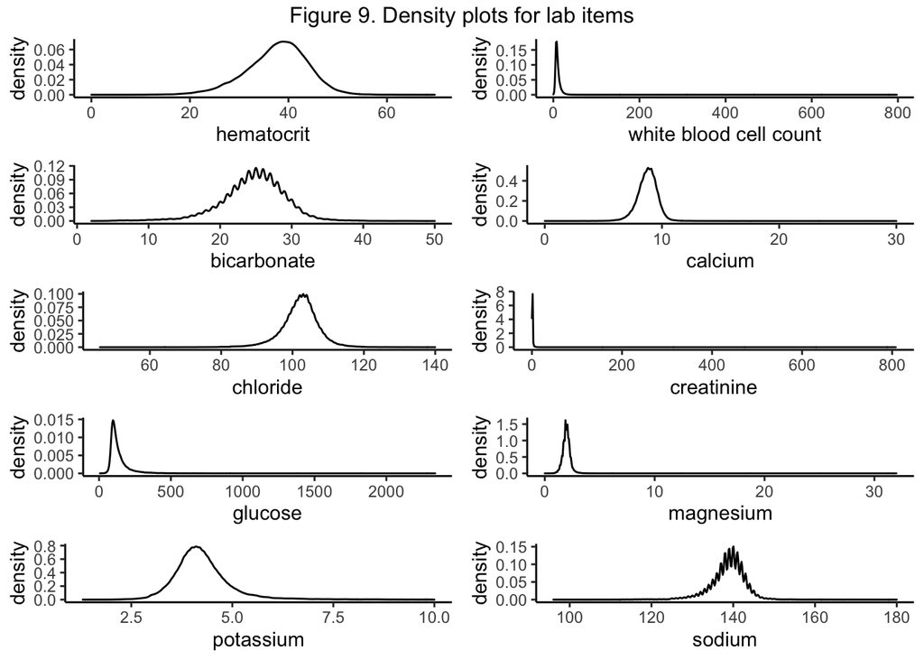

```r
labevents_tble_p <- labevents_tble %>%
  mutate(item = recode(itemid, `50912` = "creatinine", `50971` = "potassium",
                       `50983` = "sodium", `50902` = "chloride",
                       `50882` = "bicarbonate", `51221` = "hematocrit",
                       `51301` = "white blood cell count", `50931` = "glucose",
                       `50960` = "magnesium", `50893` = "calcium"))

plot <- list()
k <- 1
for (i in unique(labevents_tble_p$item)){
  plot[[k]] <- labevents_tble_p %>%
    filter(item == i) %>%
    ggplot(mapping = aes(x = valuenum)) +
    geom_density() +
    theme_classic() +
    labs(x = i)
  k <- k + 1
}

rm(labevents_tble_p)

grid.arrange(grobs = plot, ncol = 2,
             top = "Figure 9. Density plots for lab items")
```

## Q6. Vitals from charted events

`chartevents.csv.gz` (https://mimic.mit.edu/docs/iv/modules/icu/chartevents/) contains all the charted data available for a patient. During their ICU stay, the primary repository of a patient’s information is their electronic chart. The `itemid` variable indicates a single measurement type in the database. The `value` variable is the value measured for `itemid`. The first 10 lines of `chartevents.csv.gz` are

```r
system(
  str_c(
    "zcat < ",
    shQuote(str_c(mimic_path, "/icu/chartevents.csv.gz")),
    " | head"),
  intern = TRUE
)
```

```
##  [1] "subject_id,hadm_id,stay_id,charttime,storetime,itemid,value,valuenum,valueuom,warning"
##  [2] "10003700,28623837,30600691,2165-04-24 05:10:00,2165-04-24 05:11:00,228236,0,0,,0"
##  [3] "10003700,28623837,30600691,2165-04-24 05:12:00,2165-04-24 05:14:00,225067,0,0,,0"
##  [4] "10003700,28623837,30600691,2165-04-24 05:12:00,2165-04-24 05:14:00,225070,1,1,,0"
##  [5] "10003700,28623837,30600691,2165-04-24 05:12:00,2165-04-24 05:14:00,225076,1,1,,0"
##  [6] "10003700,28623837,30600691,2165-04-24 05:12:00,2165-04-24 05:14:00,225078,1,1,,0"
##  [7] "10003700,28623837,30600691,2165-04-24 05:12:00,2165-04-24 05:14:00,225086,1,1,,0"
##  [8] "10003700,28623837,30600691,2165-04-24 05:12:00,2165-04-24 05:14:00,225091,1,1,,0"
##  [9] "10003700,28623837,30600691,2165-04-24 05:12:00,2165-04-24 05:14:00,225103,1,1,,0"
## [10] "10003700,28623837,30600691,2165-04-24 05:12:00,2165-04-24 05:14:00,225106,1,1,,0"
```

`d_items.csv.gz` (https://mimic.mit.edu/docs/iv/modules/icu/d_items/) is the dictionary for the `itemid` in `chartevents.csv.gz`.

```r
system(
  str_c(
    "zcat < ",
    shQuote(str_c(mimic_path, "/icu/d_items.csv.gz")),
    " | head"),
  intern = TRUE
)
```

```
##  [1] "itemid,label,abbreviation,linksto,category,unitname,param_type,lownormalvalue,highnormalvalue"
##  [2] "220003,ICU Admission date,ICU Admission date,datetimeevents,ADT,,Date and time,,"
##  [3] "220045,Heart Rate,HR,chartevents,Routine Vital Signs,bpm,Numeric,,"
##  [4] "220046,Heart rate Alarm - High,HR Alarm - High,chartevents,Alarms,bpm,Numeric,,"
##  [5] "220047,Heart Rate Alarm - Low,HR Alarm - Low,chartevents,Alarms,bpm,Numeric,,"
##  [6] "220048,Heart Rhythm,Heart Rhythm,chartevents,Routine Vital Signs,,Text,,"
##  [7] "220050,Arterial Blood Pressure systolic,ABPs,chartevents,Routine Vital Signs,mmHg,Numeric,90,140"
##  [8] "220051,Arterial Blood Pressure diastolic,ABPd,chartevents,Routine Vital Signs,mmHg,Numeric,60,90"
##  [9] "220052,Arterial Blood Pressure mean,ABPm,chartevents,Routine Vital Signs,mmHg,Numeric,,"
## [10] "220056,Arterial Blood Pressure Alarm - Low,ABP Alarm - Low,chartevents,Alarms,mmHg,Numeric,,"
```

1. We are interested in the vitals for ICU patients: heart rate (220045), mean non-invasive blood pressure (220181), systolic non-invasive blood pressure (220179), body temperature in Fahrenheit (223761), and respiratory rate (220210). Retrieve a subset of `chartevents.csv.gz` only containing these items for the patients in `icustays_tble` as a tibble `chartevents_tble`.

```r
chartevents_tble <- read_csv(str_c(mimic_path,
                                   "/icu/chartevents_filtered_itemid.csv.gz"),
                             lazy = TRUE) %>%
  filter(itemid %in% c(220045, 220181, 220179, 223761, 220210),
         subject_id %in% icustays_tble$subject_id)
```

2. Further restrict `chartevents_tble` to the first vital measurement during the ICU stay.

```r
chartevents_tble <- chartevents_tble %>%
  arrange(charttime) %>%
  distinct(subject_id, itemid, .keep_all = TRUE)
```

3. Summarize these vital measurements by appropriate numerics and graphics.

```r
chartevents_sum <- chartevents_tble %>%
  group_by(itemid) %>%
  summarize(
    n = n(),
    mean = mean(valuenum, na.rm = TRUE),
    sd = sd(valuenum, na.rm = TRUE),
    median = median(valuenum, na.rm = TRUE),
    IQR = IQR(valuenum, na.rm = TRUE),
    min = min(valuenum, na.rm = TRUE),
    max = max(valuenum, na.rm = TRUE)
  ) %>%
  # the name of the items
  mutate(item = recode(itemid,
                       `220045` = "heart rate",
                       `220181` = "mean non-invasive BP",
                       `220179` = "systolic non-invasive BP",
                       `223761` = "body temperature in F",
                       `220210` = "respiratory rate")) %>%
  # reorder the columns
  select(itemid, item, n, mean, sd, median, IQR, min, max)

knitr::kable(chartevents_sum,
             caption = "Table 2. Summary of vital measurements")
```

Table 2. Summary of vital measurements

| itemid | item | n | mean | sd | median | IQR | min | max |
| --- | --- | --- | --- | --- | --- | --- | --- | --- |
| 220045 | heart rate | 53149 | 87.68482 | 20.197606 | 85.0 | 25.0 | 0 | 941.0 |
| 220179 | systolic non-invasive BP | 52651 | 126.35219 | 508.841820 | 122.0 | 33.0 | 0 | 116114.0 |
| 220181 | mean non-invasive BP | 52630 | 151.01473 | 14551.748027 | 81.0 | 23.0 | 0 | 3333330.0 |
| 220210 | respiratory rate | 53115 | 18.71560 | 6.276648 | 18.0 | 7.0 | 0 | 180.0 |
| 223761 | body temperature in F | 52392 | 98.01528 | 3.483071 | 98.1 | 1.1 | 0 | 106.5 |

**Answer:** Table 2 above shows the summary statistics for each vital measurements.

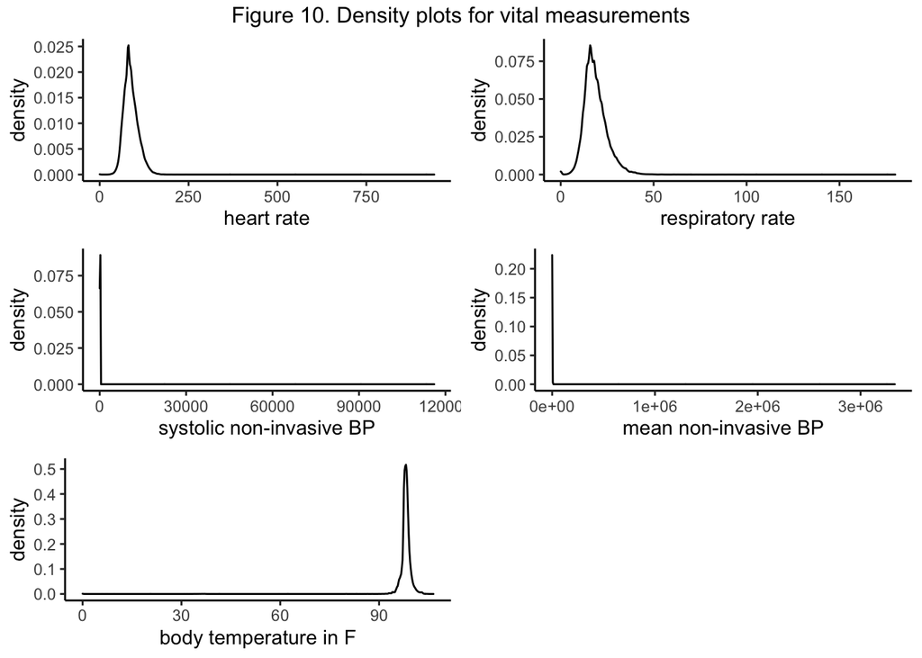

```r
chartevents_tble_p <- chartevents_tble %>%
  mutate(item = recode(itemid,
                       `220045` = "heart rate",
                       `220181` = "mean non-invasive BP",
                       `220179` = "systolic non-invasive BP",
                       `223761` = "body temperature in F",
                       `220210` = "respiratory rate"))

plot <- list()
k <- 1
for (i in unique(chartevents_tble_p$item)){
  plot[[k]] <- chartevents_tble_p %>%
    filter(item == i) %>%
    ggplot(mapping = aes(x = valuenum)) +
    geom_density() +
    theme_classic() +
    labs(x = i)
  k <- k + 1
}

grid.arrange(grobs = plot, ncol = 2,
             top = "Figure 10. Density plots for vital measurements")
```

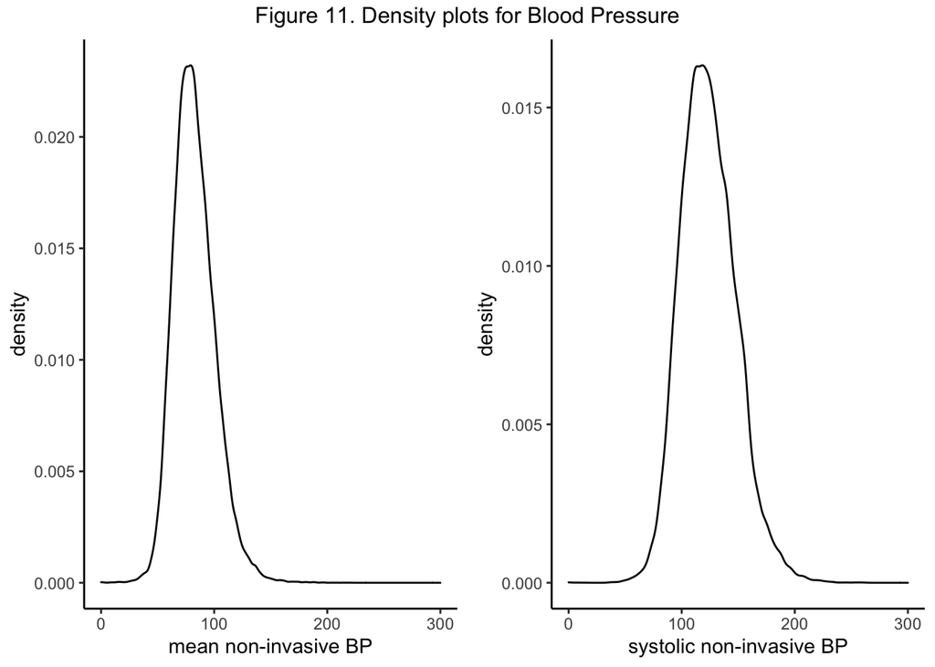

```r
plot <- list()
k <- 1
for (i in c("mean non-invasive BP", "systolic non-invasive BP")){
  plot[[k]] <- chartevents_tble_p %>%
    filter(item == i) %>%
    ggplot(mapping = aes(x = valuenum)) +
    geom_density() +
    theme_classic() +
    labs(x = i) +
    xlim(c(0, 300))
  k <- k + 1
}

rm(chartevents_tble_p)

grid.arrange(grobs = plot, ncol = 2,
             top = "Figure 11. Density plots for Blood Pressure")
```

## Q7. Putting things together

Let us create a tibble `mimic_icu_cohort` for all ICU stays, where rows are

- first ICU stay of each unique adult (age at admission > 18)

and columns contain at least following variables

- all variables in `icustays.csv.gz`
- all variables in `admission.csv.gz`
- all variables in `patients.csv.gz`
- first lab measurements during ICU stay
- first vital measurements during ICU stay
- an indicator variable `thirty_day_mort` whether the patient died within 30 days of hospital admission (30 day mortality)

```r
mimic_icu_cohort <- icustays_tble %>%
  # merge admission table to icu table
  left_join(admissions_tble, by = c("subject_id", "hadm_id")) %>%
  # merge patient table to icu table
  left_join(patients_tble, by = c("subject_id"))

# transfrom labevent and chartevent table to wide format
labevents_tble_w <- labevents_tble %>%
  select(-c(charttime)) %>%
  pivot_wider(id_cols = subject_id,
              names_from = itemid,
              names_prefix = "lab_",
              values_from = valuenum)

chartevents_tble_w <- chartevents_tble %>%
  select(subject_id, itemid, valuenum) %>%
  pivot_wider(id_cols = subject_id,
              names_from = itemid,
              names_prefix = "vital_",
              values_from = valuenum)

# merge lab and vital measurements to full dataset
mimic_icu_cohort <- mimic_icu_cohort %>%
  left_join(labevents_tble_w, by = c("subject_id")) %>%
  left_join(chartevents_tble_w, by = c("subject_id"))

# create indicator of survival within 30 days after admission
mimic_icu_cohort <- mimic_icu_cohort %>%
  mutate(
    survival_days = as.numeric((dod - as.Date(admittime))),
    thirty_day_mort = ifelse(is.na(survival_days), 0,
                          ifelse(survival_days > 30, 0, 1))
  )

# print final tibble
print(mimic_icu_cohort, width = Inf, n = 5)
```

```
## # A tibble: 53,150 × 43
##   subject_id  hadm_id  stay_id first_careunit
##        <dbl>    <dbl>    <dbl> <chr>
## 1   10000032 29079034 39553978 Medical Intensive Care Unit (MICU)
## 2   10000980 26913865 39765666 Medical Intensive Care Unit (MICU)
## 3   10001217 24597018 37067082 Surgical Intensive Care Unit (SICU)
## 4   10001725 25563031 31205490 Medical/Surgical Intensive Care Unit (MICU/SICU)
## 5   10001884 26184834 37510196 Medical Intensive Care Unit (MICU)
##   last_careunit                                    intime
##   <chr>                                            <dttm>
## 1 Medical Intensive Care Unit (MICU)               2180-07-23 14:00:00
## 2 Medical Intensive Care Unit (MICU)               2189-06-27 08:42:00
## 3 Surgical Intensive Care Unit (SICU)              2157-11-20 19:18:02
## 4 Medical/Surgical Intensive Care Unit (MICU/SICU) 2110-04-11 15:52:22
## 5 Medical Intensive Care Unit (MICU)               2131-01-11 04:20:05
##   outtime               los admittime           dischtime
##   <dttm>              <dbl> <dttm>              <dttm>
## 1 2180-07-23 23:50:47 0.410 2180-07-23 12:35:00 2180-07-25 17:55:00
## 2 2189-06-27 20:38:27 0.498 2189-06-27 07:38:00 2189-07-03 03:00:00
## 3 2157-11-21 22:08:00 1.12  2157-11-18 22:56:00 2157-11-25 18:00:00
## 4 2110-04-12 23:59:56 1.34  2110-04-11 15:08:00 2110-04-14 15:00:00
## 5 2131-01-20 08:27:30 9.17  2131-01-07 20:39:00 2131-01-20 05:15:00
##   deathtime           admission_type    admission_location discharge_location
##   <dttm>              <chr>             <chr>              <chr>
## 1 NA                  EW EMER.          EMERGENCY ROOM     HOME
## 2 NA                  EW EMER.          EMERGENCY ROOM     HOME HEALTH CARE
## 3 NA                  EW EMER.          EMERGENCY ROOM     HOME HEALTH CARE
## 4 NA                  EW EMER.          PACU               HOME
## 5 2131-01-20 05:15:00 OBSERVATION ADMIT EMERGENCY ROOM     DIED
##   insurance language marital_status ethnicity              edregtime
##   <chr>     <chr>    <chr>          <chr>                  <dttm>
## 1 Medicaid  ENGLISH  WIDOWED        WHITE                  2180-07-23 05:54:00
## 2 Medicare  ENGLISH  MARRIED        BLACK/AFRICAN AMERICAN 2189-06-27 06:25:00
## 3 Other     ?        MARRIED        WHITE                  2157-11-18 17:38:00
## 4 Other     ENGLISH  MARRIED        WHITE                  NA
## 5 Medicare  ENGLISH  MARRIED        BLACK/AFRICAN AMERICAN 2131-01-07 13:36:00
##   edouttime           hospital_expire_flag gender anchor_age anchor_year
##   <dttm>                             <dbl> <chr>       <dbl>       <dbl>
## 1 2180-07-23 14:00:00                    0 F              52        2180
## 2 2189-06-27 08:42:00                    0 F              73        2186
```

[output cut: 10 more lines]

```
##   lab_50912 lab_50931 lab_50960 lab_50971 lab_50983 vital_220045 vital_220210
##       <dbl>     <dbl>     <dbl>     <dbl>     <dbl>        <dbl>        <dbl>
## 1       0.4        95       1.8       3.7       136           91           24
## 2       2.2       153       2.3       5.1       142           77           23
## 3       0.6        86       2.3       4.4       140           86           18
## 4       0.8       146       1.5       4.1       139           55           19
## 5       0.8       106       1.8       3.6       135           38           16
##   vital_220179 vital_220181 vital_223761 survival_days thirty_day_mort
##          <dbl>        <dbl>        <dbl>         <dbl>           <dbl>
## 1           84           56         98.7            NA               0
## 2          150           92         98              NA               0
## 3          151          104         98.5            NA               0
## 4           73           59         97.7            NA               0
## 5          180           46         98.1            13               1
## # … with 53,145 more rows
```

**Answer:** the table printed above is the final tibble. **Note:** for the 30 days mortality indicator, the date of death was determined by the variable `dod`, which include more patients’ information than `deathtime`.

```r
# remove the intermediate objects
rm(list = setdiff(ls(), "mimic_icu_cohort"))
```

## Q8. Exploratory data analysis (EDA)

Summarize following information using appropriate numerics or graphs.

- `thirty_day_mort` vs demographic variables (ethnicity, language, insurance, marital_status, gender, age at hospital admission)

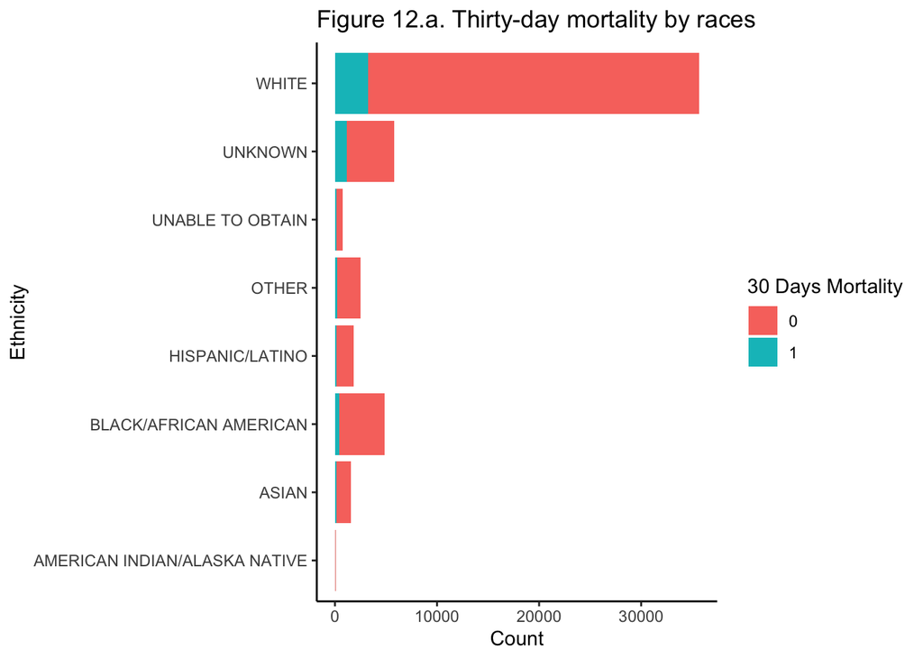

```r
# ethnicity
mimic_icu_cohort %>%
  ggplot() +
  geom_bar(mapping = aes(x = ethnicity, fill = as.factor(thirty_day_mort)),
           position = "stack") +
  coord_flip() +
  theme_classic() +
  labs(title = "Figure 12.a. Thirty-day mortality by races",
       x = "Ethnicity",
       y = "Count",
       fill = "30 Days Mortality")
```

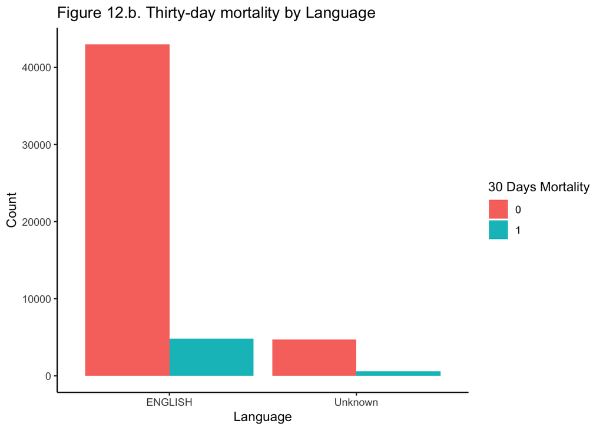

```r
# language
mimic_icu_cohort %>%
  mutate(language = recode(language, `?` = "Unknown")) %>%
  ggplot() +
  geom_bar(mapping = aes(x = language, fill = as.factor(thirty_day_mort)),
           position = "dodge") +
  theme_classic() +
  labs(title = "Figure 12.b. Thirty-day mortality by Language",
       x = "Language",
       y = "Count",
       fill = "30 Days Mortality")
```

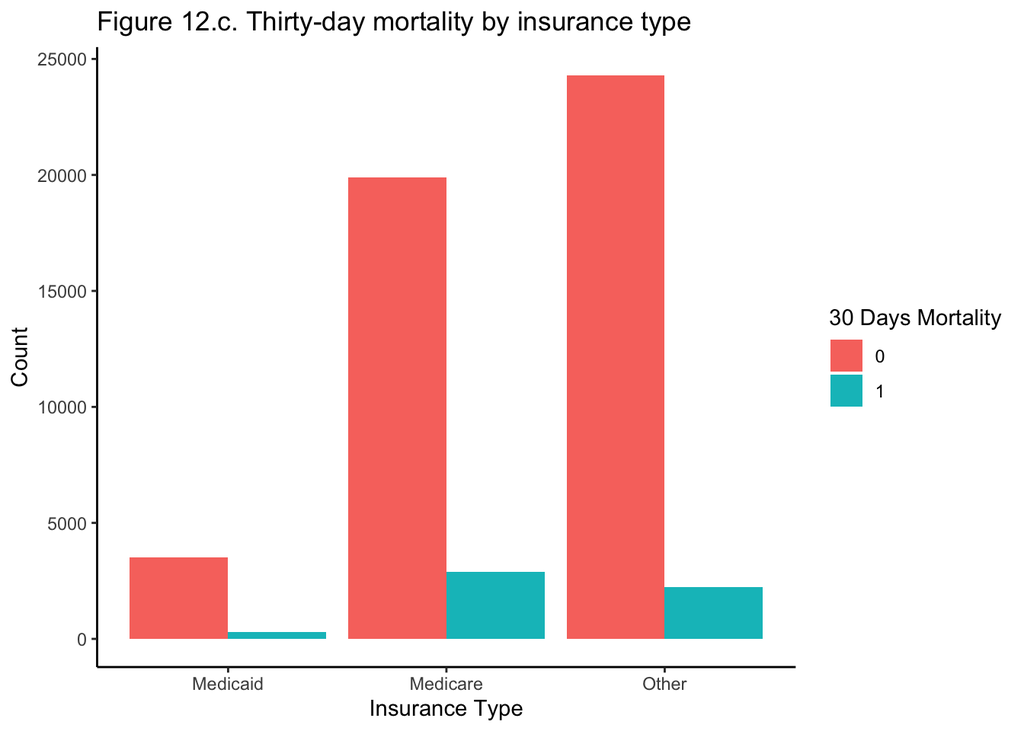

```r
# insurance
mimic_icu_cohort %>%
  ggplot() +
  geom_bar(mapping = aes(x = insurance, fill = as.factor(thirty_day_mort)),
           position = "dodge") +
  theme_classic() +
  labs(title = "Figure 12.c. Thirty-day mortality by insurance type",
       x = "Insurance Type",
       y = "Count",
       fill = "30 Days Mortality")
```

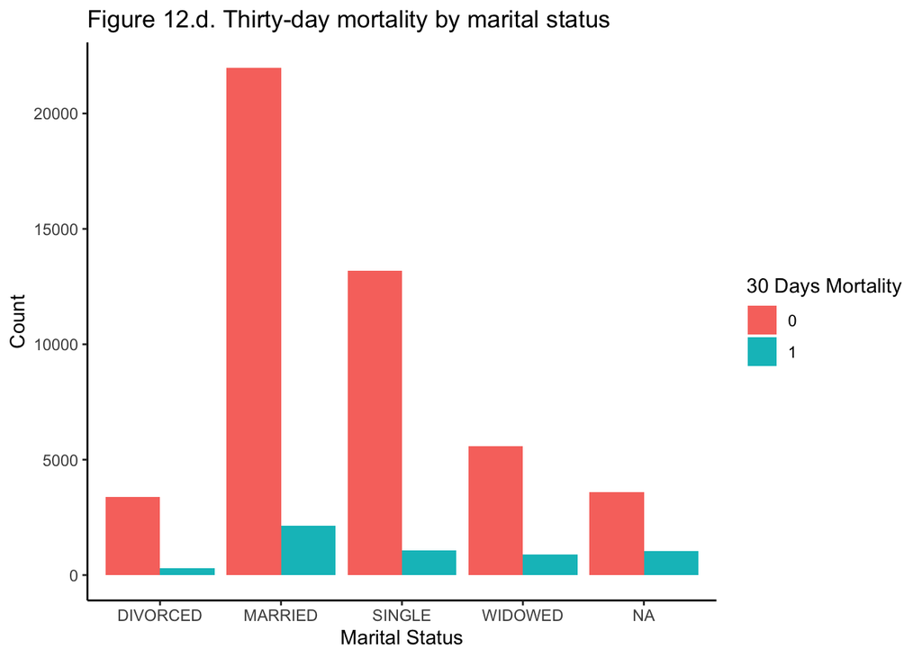

```r
# marital_status
mimic_icu_cohort %>%
  ggplot() +
  geom_bar(mapping = aes(x = marital_status, fill = as.factor(thirty_day_mort)),
           position = "dodge") +
  theme_classic() +
  labs(title = "Figure 12.d. Thirty-day mortality by marital status",
       x = "Marital Status",
       y = "Count",
       fill = "30 Days Mortality")
```

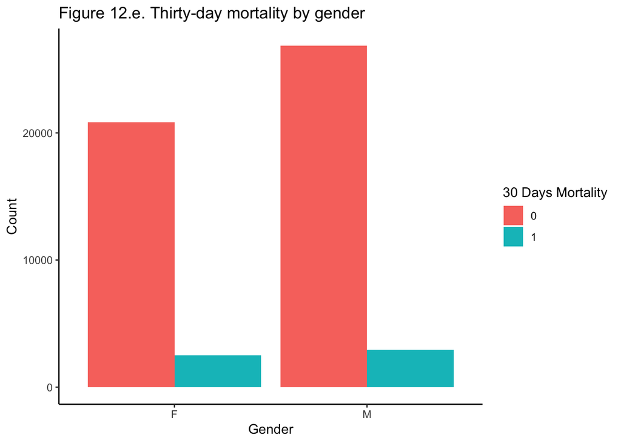

```r
# gender
mimic_icu_cohort %>%
  ggplot() +
  geom_bar(mapping = aes(x = gender, fill = as.factor(thirty_day_mort)),
           position = "dodge") +
  theme_classic() +
  labs(title = "Figure 12.e. Thirty-day mortality by gender",
       x = "Gender",
       y = "Count",
       fill = "30 Days Mortality")
```

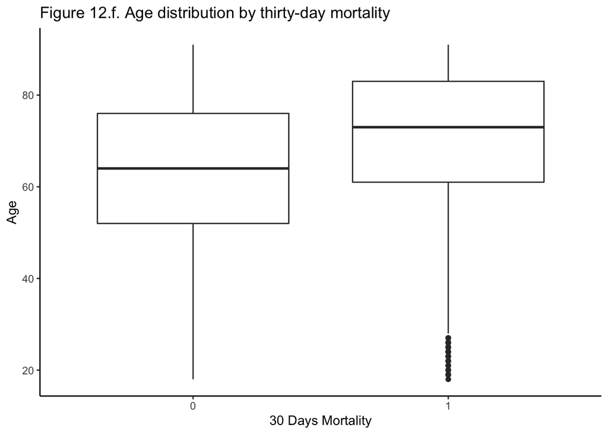

```r
# age
mimic_icu_cohort %>%
  ggplot() +
  geom_boxplot(mapping = aes(x = as.factor(thirty_day_mort),
                             y = anchor_age)) +
  theme_classic() +
  labs(title = "Figure 12.f. Age distribution by thirty-day mortality",
       x = "30 Days Mortality", y = "Age")
```

- `thirty_day_mort` vs first lab measurements

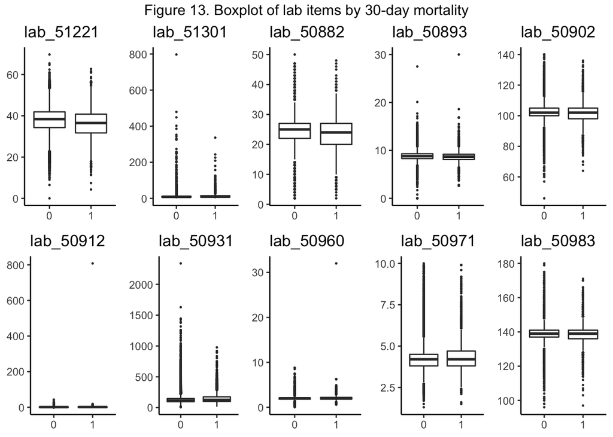

```r
tbl_plot <- mimic_icu_cohort %>%
  select(subject_id, thirty_day_mort, starts_with("lab")) %>%
  pivot_longer(starts_with("lab"),
               names_to = "lab_item",
               values_to = "value")

k <- 1
plot <- list()
for (i in unique(tbl_plot$`lab_item`)){
  plot[[k]] <- tbl_plot %>%
    filter(lab_item == i) %>%
    ggplot(mapping = aes(x = as.factor(thirty_day_mort), y = value)) +
    geom_boxplot(outlier.size = 0.3) +
    theme_classic() +
    labs(title = i, x = NULL, y = NULL)
  k <- k + 1
}

grid.arrange(grobs = plot, ncol = 5,
             top = "Figure 13. Boxplot of lab items by 30-day mortality")
```

```r
tbl_summary <- tbl_plot %>%
  group_by(thirty_day_mort, lab_item) %>%
  summarize(
    median = median(value, na.rm = TRUE),
    P25 = quantile(value, 0.25, na.rm = TRUE),
    P75 = quantile(value, 0.75, na.rm = TRUE)
  ) %>%
  mutate(
    stat = str_c(median, " (", P25, " ,", P75, ")"),
    .keep = "unused"
  ) %>%
  pivot_wider(names_from = thirty_day_mort,
              names_prefix = "30-day mortality: ",
              values_from = stat)

knitr::kable(tbl_summary, caption = "Table 3. Median, P25/75 of lab terms")
```

Table 3. Median, P25/75 of lab terms

| lab_item | 30-day mortality: 0 | 30-day mortality: 1 |
| --- | --- | --- |
| lab_50882 | 25 (22 ,27) | 24 (20 ,27) |
| lab_50893 | 8.8 (8.3 ,9.3) | 8.7 (8.1 ,9.2) |
| lab_50902 | 102 (100 ,105) | 102 (98 ,105) |
| lab_50912 | 0.9 (0.8 ,1.2) | 1.1 (0.8 ,1.6) |
| lab_50931 | 114 (96 ,147) | 126 (100 ,175) |
| lab_50960 | 2 (1.8 ,2.1) | 2 (1.8 ,2.2) |
| lab_50971 | 4.2 (3.8 ,4.5) | 4.2 (3.8 ,4.7) |
| lab_50983 | 139 (137 ,141) | 139 (136 ,141) |
| lab_51221 | 38.4 (34.3 ,41.9) | 36.5 (31.7 ,40.8) |
| lab_51301 | 8.5 (6.5 ,11.6) | 10 (6.9 ,14.9) |

**Answer:** Figure 13 shows the distribution of different lab terms by 30-day mortality. The plot does not look good due to extreme outliers. Table 3 shows the medians and quartiles of these lab terms by 30-day mortality.

- `thirty_day_mort` vs first vital measurements

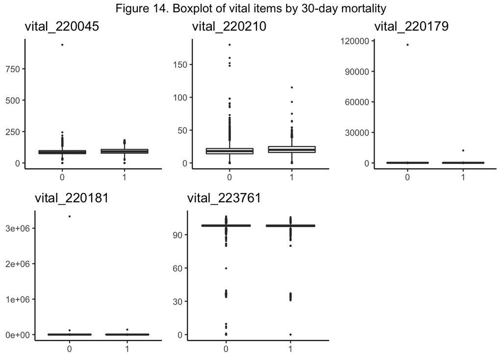

```r
tbl_plot <- mimic_icu_cohort %>%
  select(subject_id, thirty_day_mort, starts_with("vital")) %>%
  pivot_longer(starts_with("vital"),
               names_to = "vital_item",
               values_to = "value")

k <- 1
plot <- list()
for (i in unique(tbl_plot$vital_item)){
  plot[[k]] <- tbl_plot %>%
    filter(vital_item == i) %>%
    ggplot(mapping = aes(x = as.factor(thirty_day_mort), y = value)) +
    geom_boxplot(outlier.size = 0.3) +
    theme_classic() +
    labs(title = i, x = NULL, y = NULL)
  k <- k + 1
}

grid.arrange(grobs = plot, ncol = 3,
             top = "Figure 14. Boxplot of vital items by 30-day mortality")
```

```r
tbl_summary <- tbl_plot %>%
  group_by(thirty_day_mort, vital_item) %>%
  summarize(
    median = median(value, na.rm = TRUE),
    P25 = quantile(value, 0.25, na.rm = TRUE),
    P75 = quantile(value, 0.75, na.rm = TRUE)
  ) %>%
  mutate(
    stat = str_c(median, " (", P25, " ,", P75, ")"),
    .keep = "unused"
  ) %>%
  pivot_wider(names_from = thirty_day_mort,
              names_prefix = "30-day mortality: ",
              values_from = stat)

knitr::kable(tbl_summary, caption = "Table 4. Median, P25/75 of vital terms")
```

Table 4. Median, P25/75 of vital terms

| vital_item | 30-day mortality: 0 | 30-day mortality: 1 |
| --- | --- | --- |
| vital_220045 | 85 (74 ,98) | 92 (78 ,108) |
| vital_220179 | 123 (107 ,140) | 118 (101 ,138) |
| vital_220181 | 81 (70 ,93) | 79 (66 ,93) |
| vital_220210 | 18 (14 ,22) | 20 (16 ,25) |
| vital_223761 | 98.2 (97.6 ,98.7) | 98 (97.4 ,98.7) |

- `thirty_day_mort` vs first ICU unit

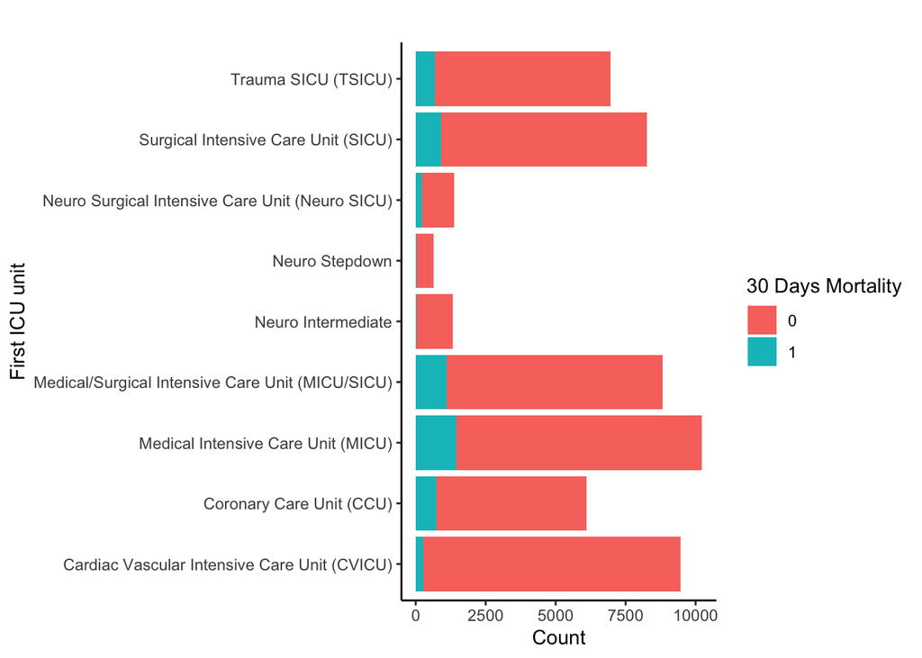

```r
mimic_icu_cohort %>%
  ggplot() +
  geom_bar(mapping = aes(x = first_careunit, fill = as.factor(thirty_day_mort)),
           position = "stack") +
  coord_flip() +
  theme_classic() +
  labs(title = "",
       x = "First ICU unit",
       y = "Count",
       fill = "30 Days Mortality")
```